# Why blocking makes a difference?

Sidhant Chaudhary

2024-07-24

# 1 Data used

The data is downloaded from https://raw.githubusercontent.com/SchmidtPaul/DSFAIR/master/data/Clewer%26Scarisbrick2001.csv

```r
dataURL <- "https://raw.githubusercontent.com/SchmidtPaul/DSFAIR/master/data/Clewer%26Scarisbrick2001.csv"
dat <- read_csv(dataURL)

dat
```

```
## # A tibble: 12 × 5
##    block cultivar yield   row   col
##    <chr> <chr>    <dbl> <dbl> <dbl>
##  1 B1    C1         7.4     2     1
##  2 B1    C2         9.8     3     1
##  3 B1    C3         7.3     1     1
##  4 B1    C4         9.5     4     1
##  5 B2    C1         6.5     1     2
##  6 B2    C2         6.8     4     2
##  7 B2    C3         6.1     3     2
##  8 B2    C4         8       2     2
##  9 B3    C1         5.6     2     3
## 10 B3    C2         6.2     1     3
## 11 B3    C3         6.4     3     3
## 12 B3    C4         7.4     4     3
```

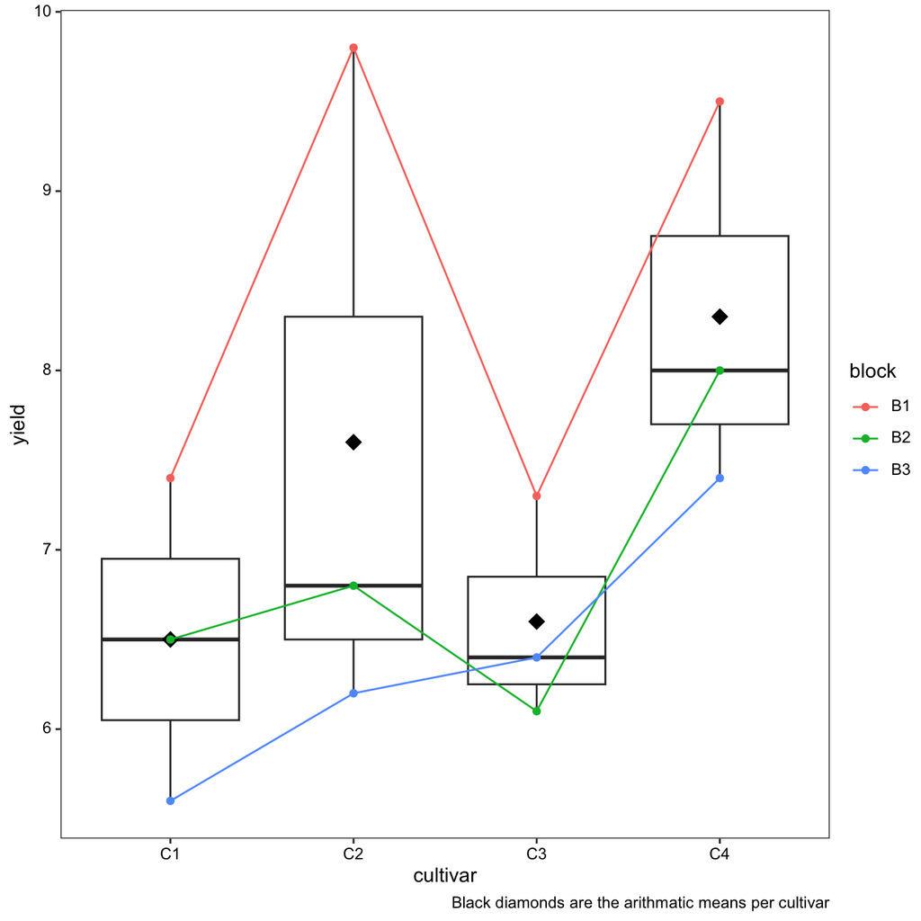

```r
# Raw data visualisation
dat %>%
  ggplot(aes(x = cultivar, y = yield)) +
  geom_boxplot(alpha = 0.1) +
  stat_summary(fun = "mean", geom = "point", shape = 18, size = 4, color = "black",
  position = position_dodge(width = 0.75), show.legend = F) +
  geom_line(aes(group = block, color = block)) +
  geom_point(aes(color = block)) +
  labs(caption = "Black diamonds are the arithmatic means per cultivar")
```

# 2 Importance of blocking when data is complete

## 2.1 Model without block effect

```r
mod_no_block <- lm(yield ~ cultivar , data = dat)
anova(mod_no_block)
```

```
## # A tibble: 2 × 5
##      Df `Sum Sq` `Mean Sq` `F value` `Pr(>F)`
##   <int>    <dbl>     <dbl>     <dbl>    <dbl>
## 1     3     6.63      2.21      1.45    0.299
## 2     8    12.2       1.52     NA      NA
```

```r
mean_comparisons_no_block <- mod_no_block %>%
  emmeans(specs = ~ cultivar) %>% # get adjusted means for cultivars
  cld(adjust="tukey", Letters=letters) # add compact letter display

mean_comparisons_no_block
```

```
## # A tibble: 4 × 7
##   cultivar emmean    SE    df lower.CL upper.CL .group
##   <fct>     <dbl> <dbl> <dbl>    <dbl>    <dbl> <chr>
## 1 C1          6.5 0.712     8     4.23     8.77 " a"
## 2 C3          6.6 0.712     8     4.33     8.87 " a"
## 3 C2          7.6 0.712     8     5.33     9.87 " a"
## 4 C4          8.3 0.712     8     6.03    10.6  " a"
```

We observe that cultivar effect is not significant according to ANOVA. Consequently, no significant difference among cultivars is observed.

## 2.2 Model with block effects

```r
mod_block <- lm(yield ~ cultivar + block, data = dat)
anova(mod_block)
```

```
## # A tibble: 3 × 5
##      Df `Sum Sq` `Mean Sq` `F value` `Pr(>F)`
##   <int>    <dbl>     <dbl>     <dbl>    <dbl>
## 1     3     6.63     2.21       5.53  0.0367
## 2     2     9.78     4.89      12.2   0.00765
## 3     6     2.40     0.400     NA    NA
```

```r
mean_comparisons_block <- mod_block %>%
  emmeans(specs = ~ cultivar) %>% # get adjusted means for cultivars
  cld(adjust="tukey", Letters=letters) # add compact letter display

mean_comparisons_block
```

```
## # A tibble: 4 × 7
##   cultivar emmean    SE    df lower.CL upper.CL .group
##   <fct>     <dbl> <dbl> <dbl>    <dbl>    <dbl> <chr>
## 1 C1         6.50 0.365     6     5.22     7.78 " a "
## 2 C3         6.6  0.365     6     5.32     7.88 " ab"
## 3 C2         7.6  0.365     6     6.32     8.88 " ab"
## 4 C4         8.3  0.365     6     7.02     9.58 "  b"
```

However, once blocks are considered in the model, cultivar effect is significant in ANOVA and consequently, we observe differences among cultivars.

After visualising the comparison of these two models with and without blocks, we see that mean estimates are the same, however, confidence intervals are more precise in the model with blocking, thereby, exposing the differences among cultivars.

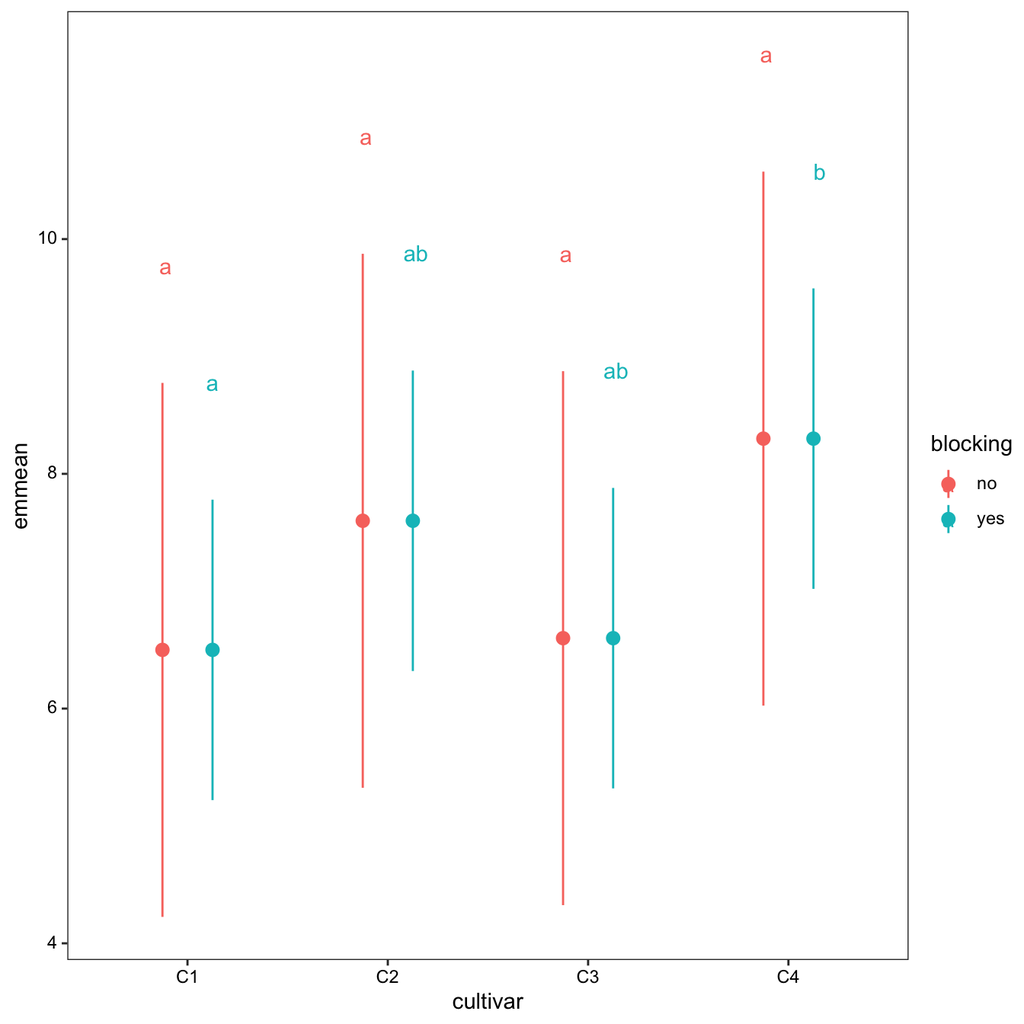

```r
mean_comparisons_no_block %>%
  as_tibble() %>%
  mutate(blocking = "no") %>%
  bind_rows(mean_comparisons_block %>%
              as_tibble() %>%
              mutate(blocking = "yes")) %>%
  ggplot(aes(x = cultivar, y = emmean, color = blocking)) +
  geom_pointrange(aes(ymin = lower.CL, ymax = upper.CL), position = position_dodge(width = 0.5)) +
  geom_text(aes(y = upper.CL + 1, label = .group), position = position_dodge(width = 0.5))
```

# 3 Importance of blocking with missing data

What happens when you miss data? Blocking becomes quite important also in cases of missing data. Let’s explore in the above data by dropping one value

```r
dat_missing <-
  dat %>%
  mutate(yield = na_if(yield, 8))

dat_missing
```

```
## # A tibble: 12 × 5
##    block cultivar yield   row   col
##    <chr> <chr>    <dbl> <dbl> <dbl>
##  1 B1    C1         7.4     2     1
##  2 B1    C2         9.8     3     1
##  3 B1    C3         7.3     1     1
##  4 B1    C4         9.5     4     1
##  5 B2    C1         6.5     1     2
##  6 B2    C2         6.8     4     2
##  7 B2    C3         6.1     3     2
##  8 B2    C4        NA       2     2
##  9 B3    C1         5.6     2     3
## 10 B3    C2         6.2     1     3
## 11 B3    C3         6.4     3     3
## 12 B3    C4         7.4     4     3
```

Cultivar 4 is missing its value from 2nd block.

## 3.1 Model on missing data with no blocks

```r
dat_missing %>%
  group_by(cultivar) %>%
  summarise(mean_yield = mean(yield, na.rm = T))
```

```
## # A tibble: 4 × 2
##   cultivar mean_yield
##   <chr>         <dbl>
## 1 C1             6.5
## 2 C2             7.6
## 3 C3             6.6
## 4 C4             8.45
```

```r
mod_miss_no_block <- lm(yield ~ cultivar, data = dat_missing)
anova(mod_miss_no_block)
```

```
## # A tibble: 2 × 5
##      Df `Sum Sq` `Mean Sq` `F value` `Pr(>F)`
##   <int>    <dbl>     <dbl>     <dbl>    <dbl>
## 1     3     6.15      2.05      1.19    0.380
## 2     7    12.0       1.72     NA      NA
```

```r
mean_comparisons_miss_no_block <- mod_miss_no_block %>%
  emmeans(specs = ~ cultivar) %>% # get adjusted means for cultivars
  cld(adjust="tukey", Letters=letters) # add compact letter display

mean_comparisons_miss_no_block
```

```
## # A tibble: 4 × 7
##   cultivar emmean    SE    df lower.CL upper.CL .group
##   <fct>     <dbl> <dbl> <dbl>    <dbl>    <dbl> <chr>
## 1 C1         6.5  0.757     7     3.98     9.02 " a"
## 2 C3         6.6  0.757     7     4.08     9.12 " a"
## 3 C2         7.6  0.757     7     5.08    10.1  " a"
## 4 C4         8.45 0.928     7     5.37    11.5  " a"
```

The mean estimate of C4 is 8.45.

## 3.2 Model on missing data with blocks

```r
mod_miss_block <- lm(yield ~ cultivar + block , data = dat_missing)
anova(mod_miss_block)
```

```
## # A tibble: 3 × 5
##      Df `Sum Sq` `Mean Sq` `F value` `Pr(>F)`
##   <int>    <dbl>     <dbl>     <dbl>    <dbl>
## 1     3     6.15     2.05       4.31   0.0749
## 2     2     9.67     4.83      10.2    0.0174
## 3     5     2.38     0.476     NA     NA
```

```r
mean_comparisons_miss_block <- mod_miss_block %>%
  emmeans(specs = ~ cultivar) %>% # get adjusted means for cultivars
  cld(adjust="tukey", Letters=letters) # add compact letter display
mean_comparisons_miss_block
```

```
## # A tibble: 4 × 7
##   cultivar emmean    SE    df lower.CL upper.CL .group
##   <fct>     <dbl> <dbl> <dbl>    <dbl>    <dbl> <chr>
## 1 C1         6.5  0.398     5     4.99     8.01 " a"
## 2 C3         6.6  0.398     5     5.09     8.11 " a"
## 3 C2         7.6  0.398     5     6.09     9.11 " a"
## 4 C4         8.23 0.514     5     6.28    10.2  " a"
```

The mean estimate of C4 is 8.23.

```r
dat %>%
  group_by(cultivar) %>%
  summarise(mean_yield = mean(yield, na.rm = T))
```

```
## # A tibble: 4 × 2
##   cultivar mean_yield
##   <chr>         <dbl>
## 1 C1              6.5
## 2 C2              7.6
## 3 C3              6.6
## 4 C4              8.3
```

The mean estimate of C4 from the model with blocks is closer to the arithmatic mean of 8.3.

The plot below also shows the narrower confidence intervals alongside a better estimate of mean in case of missing data.

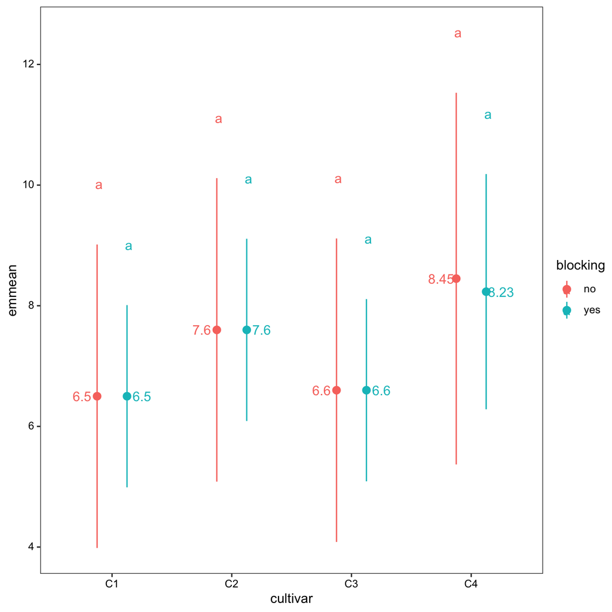

```r
mean_comparisons_miss_no_block %>%
  as_tibble() %>%
  mutate(blocking = "no") %>%
  bind_rows(mean_comparisons_miss_block %>%
              as_tibble() %>%
              mutate(blocking = "yes")) %>%
  ggplot(aes(x = cultivar, y = emmean, color = blocking)) +
  geom_pointrange(aes(ymin = lower.CL, ymax = upper.CL), position = position_dodge(width = 0.5)) +
  geom_text(aes(y = upper.CL + 1, label = .group), position = position_dodge(width = 0.5)) +
geom_text(aes(y = emmean, label = round(emmean, 2)), position = position_dodge(width = 1))
```

# 4 Conclusion

In conclusion, blocking is important for the following reasons:

- More precise estimates, smaller confidence intervals
- More correct estimates in case of missing data